# ANCOVA in TDE - Escrita (TDE - Escrita)

Geiser C. Challco geiser@alumni.usp.br

- Descriptive Statistics of Initial Data
- ANCOVA and Pairwise for one factor: **grupo**
  - Without remove non-normal data
  - Computing ANCOVA and PairWise After removing non-normal data (OK)
    - Plots for ancova
    - Checking linearity assumption
    - Checking normality and homogeneity
- ANCOVA and Pairwise for two factors **grupo:Sexo**
  - Without remove non-normal data
  - Computing ANCOVA and PairWise After removing non-normal data (OK)
    - Plots for ancova
    - Checking linearity assumption
    - Checking normality and homogeneity
- ANCOVA and Pairwise for two factors **grupo:Zona**
  - Without remove non-normal data
  - Computing ANCOVA and PairWise After removing non-normal data (OK)
    - Plots for ancova
    - Checking linearity assumption
    - Checking normality and homogeneity
- ANCOVA and Pairwise for two factors **grupo:Cor.Raca**
  - Without remove non-normal data
  - Computing ANCOVA and PairWise After removing non-normal data (OK)
    - Plots for ancova
    - Checking linearity assumption
    - Checking normality and homogeneity
- ANCOVA and Pairwise for two factors **grupo:Serie**
  - Without remove non-normal data
  - Computing ANCOVA and PairWise After removing non-normal data (OK)
    - Plots for ancova
    - Checking linearity assumption
    - Checking normality and homogeneity
- Summary of Results
  - Descriptive Statistics
  - ANCOVA Table Comparison
  - PairWise Table Comparison
  - EMMS Table Comparison

**NOTE**:

- Teste ANCOVA para determinar se houve diferenças significativas no TDE - Escrita (medido usando pre- e pos-testes).
- ANCOVA test to determine whether there were significant differences in TDE - Escrita (measured using pre- and post-tests).

# Descriptive Statistics of Initial Data

```r
df <- get.descriptives(dat, c(dv.pre, dv.pos), c("grupo"),
                       include.global = T, symmetry.test = T, normality.test = F)
df <- plyr::rbind.fill(
  df, do.call(plyr::rbind.fill, lapply(lfatores2, FUN = function(f) {
    if (nrow(dat) > 0 && sum(!is.na(unique(dat[[f]]))) > 1)
      get.descriptives(dat, c(dv.pre,dv.pos), c("grupo", f),
                       symmetry.test = T, normality.test = F)
    }))
)
(df <- df[,c(fatores1[fatores1 %in% colnames(df)],"variable",
             colnames(df)[!colnames(df) %in% c(fatores1,"variable")])])
```

```
##           grupo Sexo   Zona Cor.Raca Serie      variable   n   mean median min max     sd    se     ci
## 1      Controle <NA>   <NA>     <NA>  <NA> score.tde.pre 113  9.230   10.0   0  18  5.560 0.523  1.036
## 2  Experimental <NA>   <NA>     <NA>  <NA> score.tde.pre 112  9.777   10.0   0  18  5.445 0.515  1.020
## 3          <NA> <NA>   <NA>     <NA>  <NA> score.tde.pre 225  9.502   10.0   0  18  5.498 0.367  0.722
## 4      Controle <NA>   <NA>     <NA>  <NA> score.tde.pos 113  8.522    5.0   0  44  8.588 0.808  1.601
## 5  Experimental <NA>   <NA>     <NA>  <NA> score.tde.pos 112 11.384   10.0   0  51  9.500 0.898  1.779
## 6          <NA> <NA>   <NA>     <NA>  <NA> score.tde.pos 225  9.947    8.0   0  51  9.146 0.610  1.202
## 7      Controle    F   <NA>     <NA>  <NA> score.tde.pre  38  9.553   10.0   0  18  5.249 0.851  1.725
## 8      Controle    M   <NA>     <NA>  <NA> score.tde.pre  75  9.067   10.0   0  18  5.738 0.663  1.320
## 9  Experimental    F   <NA>     <NA>  <NA> score.tde.pre  49 10.510   12.0   0  18  5.579 0.797  1.603
## 10 Experimental    M   <NA>     <NA>  <NA> score.tde.pre  63  9.206    9.0   0  18  5.313 0.669  1.338
## 11     Controle    F   <NA>     <NA>  <NA> score.tde.pos  38  9.395    8.0   0  44  9.111 1.478  2.995
## 12     Controle    M   <NA>     <NA>  <NA> score.tde.pos  75  8.080    4.0   0  26  8.339 0.963  1.919
## 13 Experimental    F   <NA>     <NA>  <NA> score.tde.pos  49 10.980   10.0   0  51  9.123 1.303  2.620
## 14 Experimental    M   <NA>     <NA>  <NA> score.tde.pos  63 11.698    9.0   0  43  9.845 1.240  2.479
```

[output cut: 98 more lines]

| grupo | Sexo | Zona | Cor.Raca | Serie | variable | n | mean | median | min | max | sd | se | ci | iqr | symmetry | skewness | kurtosis |
| --- | --- | --- | --- | --- | --- | --- | --- | --- | --- | --- | --- | --- | --- | --- | --- | --- | --- |
| Controle |  |  |  |  | score.tde.pre | 113 | 9.230 | 10.0 | 0 | 18 | 5.560 | 0.523 | 1.036 | 9.00 | YES | -0.093 | -1.227 |
| Experimental |  |  |  |  | score.tde.pre | 112 | 9.777 | 10.0 | 0 | 18 | 5.445 | 0.515 | 1.020 | 9.25 | YES | -0.202 | -1.150 |
|  |  |  |  |  | score.tde.pre | 225 | 9.502 | 10.0 | 0 | 18 | 5.498 | 0.367 | 0.722 | 9.00 | YES | -0.149 | -1.178 |
| Controle |  |  |  |  | score.tde.pos | 113 | 8.522 | 5.0 | 0 | 44 | 8.588 | 0.808 | 1.601 | 12.00 | NO | 1.083 | 1.171 |
| Experimental |  |  |  |  | score.tde.pos | 112 | 11.384 | 10.0 | 0 | 51 | 9.500 | 0.898 | 1.779 | 12.00 | NO | 1.241 | 2.205 |
|  |  |  |  |  | score.tde.pos | 225 | 9.947 | 8.0 | 0 | 51 | 9.146 | 0.610 | 1.202 | 12.00 | NO | 1.188 | 1.942 |
| Controle | F |  |  |  | score.tde.pre | 38 | 9.553 | 10.0 | 0 | 18 | 5.249 | 0.851 | 1.725 | 9.00 | YES | 0.018 | -1.240 |
| Controle | M |  |  |  | score.tde.pre | 75 | 9.067 | 10.0 | 0 | 18 | 5.738 | 0.663 | 1.320 | 9.00 | YES | -0.120 | -1.298 |
| Experimental | F |  |  |  | score.tde.pre | 49 | 10.510 | 12.0 | 0 | 18 | 5.579 | 0.797 | 1.603 | 10.00 | YES | -0.453 | -1.070 |
| Experimental | M |  |  |  | score.tde.pre | 63 | 9.206 | 9.0 | 0 | 18 | 5.313 | 0.669 | 1.338 | 8.00 | YES | -0.010 | -1.141 |
| Controle | F |  |  |  | score.tde.pos | 38 | 9.395 | 8.0 | 0 | 44 | 9.111 | 1.478 | 2.995 | 11.75 | NO | 1.705 | 3.563 |
| Controle | M |  |  |  | score.tde.pos | 75 | 8.080 | 4.0 | 0 | 26 | 8.339 | 0.963 | 1.919 | 14.00 | NO | 0.627 | -1.062 |
| Experimental | F |  |  |  | score.tde.pos | 49 | 10.980 | 10.0 | 0 | 51 | 9.123 | 1.303 | 2.620 | 12.00 | NO | 1.735 | 5.335 |
| Experimental | M |  |  |  | score.tde.pos | 63 | 11.698 | 9.0 | 0 | 43 | 9.845 | 1.240 | 2.479 | 14.00 | NO | 0.896 | 0.293 |
| Controle |  | Rural |  |  | score.tde.pre | 68 | 9.059 | 8.5 | 0 | 18 | 5.361 | 0.650 | 1.298 | 8.00 | YES | -0.031 | -1.174 |
| Controle |  | Urbana |  |  | score.tde.pre | 16 | 9.062 | 10.5 | 1 | 18 | 6.115 | 1.529 | 3.259 | 10.75 | YES | -0.124 | -1.706 |
| Controle |  |  |  |  | score.tde.pre | 29 | 9.724 | 11.0 | 0 | 18 | 5.873 | 1.091 | 2.234 | 9.00 | YES | -0.202 | -1.266 |
| Experimental |  | Rural |  |  | score.tde.pre | 62 | 9.645 | 10.0 | 0 | 18 | 5.812 | 0.738 | 1.476 | 10.00 | YES | -0.064 | -1.365 |
| Experimental |  | Urbana |  |  | score.tde.pre | 26 | 8.654 | 9.0 | 0 | 17 | 4.955 | 0.972 | 2.002 | 6.50 | YES | -0.110 | -0.859 |
| Experimental |  |  |  |  | score.tde.pre | 24 | 11.333 | 13.0 | 0 | 17 | 4.779 | 0.976 | 2.018 | 7.00 | NO | -0.818 | -0.468 |
| Controle |  | Rural |  |  | score.tde.pos | 68 | 8.015 | 5.0 | 0 | 44 | 8.474 | 1.028 | 2.051 | 13.00 | NO | 1.398 | 2.935 |
| Controle |  | Urbana |  |  | score.tde.pos | 16 | 7.000 | 4.0 | 0 | 24 | 7.925 | 1.981 | 4.223 | 7.50 | NO | 1.071 | -0.344 |
| Controle |  |  |  |  | score.tde.pos | 29 | 10.552 | 8.0 | 0 | 28 | 9.128 | 1.695 | 3.472 | 15.00 | YES | 0.378 | -1.321 |
| Experimental |  | Rural |  |  | score.tde.pos | 62 | 10.952 | 12.0 | 0 | 29 | 7.968 | 1.012 | 2.023 | 12.00 | YES | 0.333 | -0.780 |
| Experimental |  | Urbana |  |  | score.tde.pos | 26 | 9.808 | 6.0 | 0 | 43 | 10.789 | 2.116 | 4.358 | 6.00 | NO | 1.698 | 2.145 |
| Experimental |  |  |  |  | score.tde.pos | 24 | 14.208 | 12.0 | 0 | 51 | 11.360 | 2.319 | 4.797 | 14.25 | NO | 1.323 | 2.085 |
| Controle |  |  | Branca |  | score.tde.pre | 8 | 9.875 | 11.0 | 2 | 15 | 4.612 | 1.630 | 3.855 | 6.50 | YES | -0.389 | -1.532 |
| Controle |  |  | Indígena |  | score.tde.pre | 2 | 10.000 | 10.0 | 4 | 16 | 8.485 | 6.000 | 76.237 | 6.00 | few data | 0.000 | 0.000 |
| Controle |  |  | Parda |  | score.tde.pre | 39 | 8.026 | 7.0 | 0 | 18 | 5.847 | 0.936 | 1.895 | 10.00 | YES | 0.170 | -1.332 |
| Controle |  |  |  |  | score.tde.pre | 64 | 9.859 | 11.0 | 0 | 18 | 5.427 | 0.678 | 1.356 | 9.00 | YES | -0.199 | -1.139 |
| Experimental |  |  | Branca |  | score.tde.pre | 17 | 9.471 | 9.0 | 0 | 18 | 6.345 | 1.539 | 3.263 | 11.00 | YES | -0.093 | -1.650 |
| Experimental |  |  | Indígena |  | score.tde.pre | 5 | 7.800 | 6.0 | 6 | 15 | 4.025 | 1.800 | 4.998 | 0.00 | few data | 0.000 | 0.000 |
| Experimental |  |  | Parda |  | score.tde.pre | 39 | 8.949 | 9.0 | 0 | 18 | 5.596 | 0.896 | 1.814 | 9.00 | YES | 0.059 | -1.330 |
| Experimental |  |  |  |  | score.tde.pre | 51 | 10.706 | 11.0 | 0 | 18 | 5.100 | 0.714 | 1.434 | 7.00 | NO | -0.543 | -0.624 |
| Controle |  |  | Branca |  | score.tde.pos | 8 | 4.750 | 3.5 | 0 | 15 | 5.726 | 2.024 | 4.787 | 6.00 | NO | 0.753 | -1.216 |
| Controle |  |  | Indígena |  | score.tde.pos | 2 | 10.000 | 10.0 | 4 | 16 | 8.485 | 6.000 | 76.237 | 6.00 | few data | 0.000 | 0.000 |
| Controle |  |  | Parda |  | score.tde.pos | 39 | 7.359 | 4.0 | 0 | 27 | 7.531 | 1.206 | 2.441 | 12.00 | NO | 0.888 | -0.212 |
| Controle |  |  |  |  | score.tde.pos | 64 | 9.656 | 7.0 | 0 | 44 | 9.386 | 1.173 | 2.345 | 14.00 | NO | 0.999 | 0.945 |
| Experimental |  |  | Branca |  | score.tde.pos | 17 | 12.353 | 12.0 | 0 | 36 | 10.416 | 2.526 | 5.355 | 16.00 | YES | 0.487 | -0.750 |
| Experimental |  |  | Indígena |  | score.tde.pos | 5 | 14.400 | 17.0 | 1 | 23 | 8.295 | 3.709 | 10.299 | 5.00 | NO | -0.599 | -1.397 |
| Experimental |  |  | Parda |  | score.tde.pos | 39 | 10.846 | 8.0 | 0 | 51 | 10.284 | 1.647 | 3.334 | 11.00 | NO | 1.695 | 3.760 |
| Experimental |  |  |  |  | score.tde.pos | 51 | 11.176 | 10.0 | 0 | 43 | 8.847 | 1.239 | 2.488 | 10.50 | NO | 1.159 | 1.645 |
| Controle |  |  |  | 6 ano | score.tde.pre | 55 | 8.727 | 8.0 | 0 | 18 | 5.345 | 0.721 | 1.445 | 9.00 | YES | 0.051 | -1.297 |
| Controle |  |  |  | 7 ano | score.tde.pre | 34 | 10.176 | 11.0 | 0 | 18 | 5.589 | 0.959 | 1.950 | 8.00 | YES | -0.237 | -1.121 |
| Controle |  |  |  | 8 ano | score.tde.pre | 10 | 8.800 | 10.0 | 0 | 18 | 7.223 | 2.284 | 5.167 | 13.25 | YES | -0.085 | -1.871 |
| Controle |  |  |  | 9 ano | score.tde.pre | 14 | 9.214 | 10.0 | 0 | 17 | 5.352 | 1.430 | 3.090 | 8.50 | YES | -0.236 | -1.339 |
| Experimental |  |  |  | 6 ano | score.tde.pre | 47 | 9.234 | 9.0 | 0 | 18 | 5.760 | 0.840 | 1.691 | 10.00 | YES | -0.001 | -1.348 |
| Experimental |  |  |  | 7 ano | score.tde.pre | 26 | 11.885 | 11.5 | 0 | 18 | 4.546 | 0.892 | 1.836 | 6.00 | YES | -0.468 | -0.314 |
| Experimental |  |  |  | 8 ano | score.tde.pre | 27 | 9.037 | 10.0 | 0 | 16 | 5.034 | 0.969 | 1.992 | 8.00 | YES | -0.260 | -1.313 |
| Experimental |  |  |  | 9 ano | score.tde.pre | 12 | 9.000 | 10.5 | 0 | 17 | 6.310 | 1.822 | 4.009 | 11.50 | YES | -0.040 | -1.769 |
| Controle |  |  |  | 6 ano | score.tde.pos | 55 | 7.036 | 4.0 | 0 | 44 | 8.542 | 1.152 | 2.309 | 11.00 | NO | 1.886 | 4.535 |
| Controle |  |  |  | 7 ano | score.tde.pos | 34 | 8.559 | 8.5 | 0 | 24 | 7.178 | 1.231 | 2.505 | 12.00 | YES | 0.340 | -1.118 |
| Controle |  |  |  | 8 ano | score.tde.pos | 10 | 7.100 | 3.0 | 0 | 21 | 8.774 | 2.775 | 6.277 | 14.00 | NO | 0.555 | -1.583 |
| Controle |  |  |  | 9 ano | score.tde.pos | 14 | 15.286 | 15.0 | 0 | 28 | 9.384 | 2.508 | 5.418 | 15.00 | YES | -0.191 | -1.491 |
| Experimental |  |  |  | 6 ano | score.tde.pos | 47 | 9.681 | 7.0 | 0 | 29 | 7.667 | 1.118 | 2.251 | 11.00 | NO | 0.614 | -0.653 |
| Experimental |  |  |  | 7 ano | score.tde.pos | 26 | 12.308 | 10.0 | 0 | 43 | 10.525 | 2.064 | 4.251 | 11.50 | NO | 1.258 | 1.234 |
| Experimental |  |  |  | 8 ano | score.tde.pos | 27 | 12.074 | 10.0 | 0 | 51 | 10.820 | 2.082 | 4.280 | 12.50 | NO | 1.613 | 3.658 |
| Experimental |  |  |  | 9 ano | score.tde.pos | 12 | 14.500 | 14.5 | 0 | 29 | 10.501 | 3.031 | 6.672 | 20.25 | YES | 0.090 | -1.694 |

# ANCOVA and Pairwise for one factor: **grupo**

## Without remove non-normal data

```r
pdat = remove_group_data(dat[!is.na(dat[["grupo"]]),], "score.tde.pos", "grupo")

pdat.long <- rbind(pdat[,c("id","grupo")], pdat[,c("id","grupo")])
pdat.long[["time"]] <- c(rep("pre", nrow(pdat)), rep("pos", nrow(pdat)))
pdat.long[["time"]] <- factor(pdat.long[["time"]], c("pre","pos"))
pdat.long[["score.tde"]] <- c(pdat[["score.tde.pre"]], pdat[["score.tde.pos"]])

aov = anova_test(pdat, score.tde.pos ~ score.tde.pre + grupo)
laov[["grupo"]] <- get_anova_table(aov)
```

```r
pwc <- emmeans_test(pdat, score.tde.pos ~ grupo, covariate = score.tde.pre,
                    p.adjust.method = "bonferroni")
```

```r
pwc.long <- emmeans_test(dplyr::group_by_at(pdat.long, "grupo"),
                          score.tde ~ time,
                          p.adjust.method = "bonferroni")
lpwc[["grupo"]] <- plyr::rbind.fill(pwc, pwc.long)
```

```r
ds <- get.descriptives(pdat, "score.tde.pos", "grupo", covar = "score.tde.pre")
ds <- merge(ds[ds$variable != "score.tde.pre",],
            ds[ds$variable == "score.tde.pre", !colnames(ds) %in% c("variable")],
            by = "grupo", all.x = T, suffixes = c("", ".score.tde.pre"))
ds <- merge(get_emmeans(pwc), ds, by = "grupo", suffixes = c(".emms", ""))
ds <- ds[,c("grupo","n","mean.score.tde.pre","se.score.tde.pre","mean","se","emmean","se.emms")]

colnames(ds) <- c("grupo", "N", paste0(c("M","SE")," (pre)"),
                  paste0(c("M","SE"), " (unadj)"), paste0(c("M", "SE"), " (adj)"))

lemms[["grupo"]] <- ds
```

## Computing ANCOVA and PairWise After removing non-normal data (OK)

```r
wdat = pdat

res = residuals(lm(score.tde.pos ~ score.tde.pre + grupo, data = wdat))
non.normal = getNonNormal(res, wdat$id, plimit = 0.05)

wdat = wdat[!wdat$id %in% non.normal,]

wdat.long <- rbind(wdat[,c("id","grupo")], wdat[,c("id","grupo")])
wdat.long[["time"]] <- c(rep("pre", nrow(wdat)), rep("pos", nrow(wdat)))
wdat.long[["time"]] <- factor(wdat.long[["time"]], c("pre","pos"))
wdat.long[["score.tde"]] <- c(wdat[["score.tde.pre"]], wdat[["score.tde.pos"]])

ldat[["grupo"]] = wdat

(non.normal)
```

```
## [1] "P3637" "P1971" "P809"  "P2004" "P3240" "P1691" "P1110" "P2373"
```

```r
aov = anova_test(wdat, score.tde.pos ~ score.tde.pre + grupo)
laov[["grupo"]] <- merge(get_anova_table(aov), laov[["grupo"]], by="Effect", suffixes = c("","'"))

(df = get_anova_table(aov))
```

```
## ANOVA Table (type II tests)
##
##          Effect DFn DFd      F        p p<.05   ges
## 1 score.tde.pre   1 214 85.987 2.03e-17     * 0.287
## 2         grupo   1 214  6.302 1.30e-02     * 0.029
```

| Effect | DFn | DFd | F | p | p<.05 | ges |
| --- | --- | --- | --- | --- | --- | --- |
| score.tde.pre | 1 | 214 | 85.987 | 0.000 | * | 0.287 |
| grupo | 1 | 214 | 6.302 | 0.013 | * | 0.029 |

| term | .y. | group1 | group2 | df | statistic | p | p.adj | p.adj.signif |
| --- | --- | --- | --- | --- | --- | --- | --- | --- |
| score.tde.pre*grupo | score.tde.pos | Controle | Experimental | 214 | -2.51 | 0.013 | 0.013 | * |

```r
pwc.long <- emmeans_test(dplyr::group_by_at(wdat.long, "grupo"),
                         score.tde ~ time,
                         p.adjust.method = "bonferroni")
lpwc[["grupo"]] <- merge(plyr::rbind.fill(pwc, pwc.long), lpwc[["grupo"]], by=c("grupo","term",".y.","group1","group2"), suffixes = c("","'"))
```

| grupo | term | .y. | group1 | group2 | df | statistic | p | p.adj | p.adj.signif |
| --- | --- | --- | --- | --- | --- | --- | --- | --- | --- |
| Controle | time | score.tde | pre | pos | 430 | 1.571 | 0.117 | 0.117 | ns |
| Experimental | time | score.tde | pre | pos | 430 | -0.713 | 0.476 | 0.476 | ns |

```r
ds <- get.descriptives(wdat, "score.tde.pos", "grupo", covar = "score.tde.pre")
ds <- merge(ds[ds$variable != "score.tde.pre",],
            ds[ds$variable == "score.tde.pre", !colnames(ds) %in% c("variable")],
            by = "grupo", all.x = T, suffixes = c("", ".score.tde.pre"))
ds <- merge(get_emmeans(pwc), ds, by = "grupo", suffixes = c(".emms", ""))
ds <- ds[,c("grupo","n","mean.score.tde.pre","se.score.tde.pre","mean","se","emmean","se.emms")]

colnames(ds) <- c("grupo", "N", paste0(c("M","SE")," (pre)"),
                  paste0(c("M","SE"), " (unadj)"), paste0(c("M", "SE"), " (adj)"))

lemms[["grupo"]] <- merge(ds, lemms[["grupo"]], by=c("grupo"), suffixes = c("","'"))
```

| grupo | N | M (pre) | SE (pre) | M (unadj) | SE (unadj) | M (adj) | SE (adj) |
| --- | --- | --- | --- | --- | --- | --- | --- |
| Controle | 109 | 9.165 | 0.534 | 7.743 | 0.720 | 7.941 | 0.621 |
| Experimental | 108 | 9.704 | 0.531 | 10.352 | 0.749 | 10.152 | 0.624 |

### Plots for ancova

```r
plots <- oneWayAncovaPlots(
  wdat, "score.tde.pos", "grupo", aov, list("grupo"=pwc), addParam = c("mean_se"),
  font.label.size=10, step.increase=0.05, p.label="p.adj",
  subtitle = which(aov$Effect == "grupo"))
```

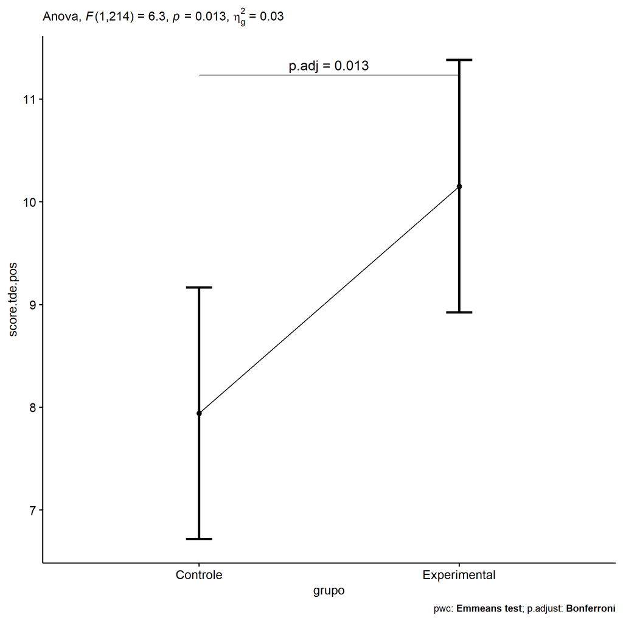

```r
if (!is.null(nrow(plots[["grupo"]]$data)))
  plots[["grupo"]] + ggplot2::scale_color_manual(values = color[["grupo"]])
```

```r
plots <- oneWayAncovaBoxPlots(
  wdat, "score.tde.pos", "grupo", aov, pwc, covar = "score.tde.pre",
  theme = "classic", color = color[["grupo"]],
  subtitle = which(aov$Effect == "grupo"))
```

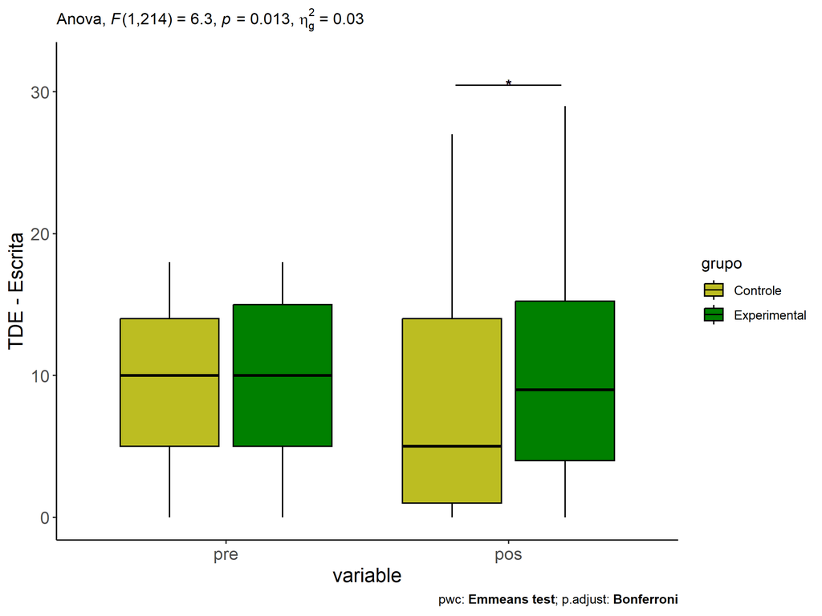

```r
if (length(unique(wdat[["grupo"]])) > 1)
  plots[["grupo"]] + ggplot2::ylab("TDE - Escrita") + ggplot2::scale_x_discrete(labels=c('pre', 'pos'))
```

```r
if (length(unique(wdat.long[["grupo"]])) > 1)
  plots <- oneWayAncovaBoxPlots(
    wdat.long, "score.tde", "grupo", aov, pwc.long, pre.post = "time",
    theme = "classic", color = color$prepost)
```

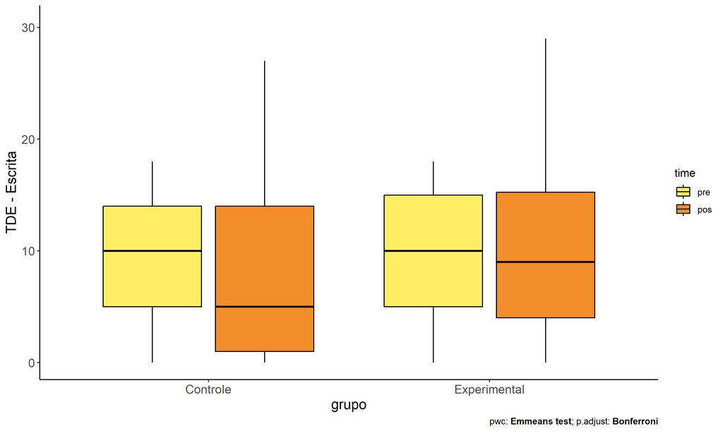

```r
if (length(unique(wdat.long[["grupo"]])) > 1)
  plots[["grupo"]] + ggplot2::ylab("TDE - Escrita")
```

### Checking linearity assumption

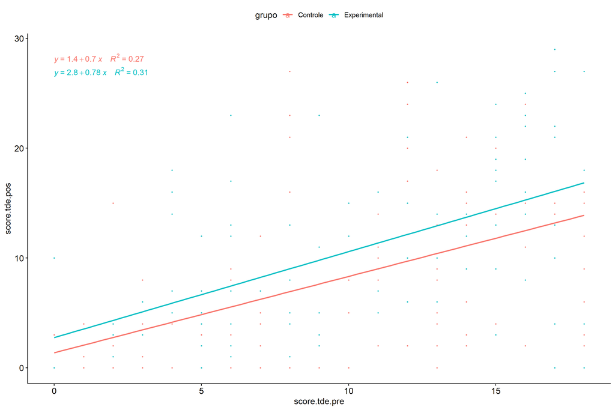

```r
ggscatter(wdat, x = "score.tde.pre", y = "score.tde.pos", size = 0.5,
          color = "grupo", add = "reg.line")+
  stat_regline_equation(
    aes(label =  paste(..eq.label.., ..rr.label.., sep = "~~~~"), color = grupo)
  )
```

### Checking normality and homogeneity

```r
res <- augment(lm(score.tde.pos ~ score.tde.pre + grupo, data = wdat))
```

```r
shapiro_test(res$.resid)
```

```
## # A tibble: 1 × 3
##   variable   statistic p.value
##   <chr>          <dbl>   <dbl>
## 1 res$.resid     0.985  0.0198
```

```r
levene_test(res, .resid ~ grupo)
```

```
## # A tibble: 1 × 4
##     df1   df2 statistic     p
##   <int> <int>     <dbl> <dbl>
## 1     1   215     0.220 0.640
```

# ANCOVA and Pairwise for two factors **grupo:Sexo**

## Without remove non-normal data

```r
pdat = remove_group_data(dat[!is.na(dat[["grupo"]]) & !is.na(dat[["Sexo"]]),], "score.tde.pos", c("grupo","Sexo"))

pdat.long <- rbind(pdat[,c("id","grupo","Sexo")], pdat[,c("id","grupo","Sexo")])
pdat.long[["time"]] <- c(rep("pre", nrow(pdat)), rep("pos", nrow(pdat)))
pdat.long[["time"]] <- factor(pdat.long[["time"]], c("pre","pos"))
pdat.long[["score.tde"]] <- c(pdat[["score.tde.pre"]], pdat[["score.tde.pos"]])

aov = anova_test(pdat, score.tde.pos ~ score.tde.pre + grupo*Sexo)
laov[["grupo:Sexo"]] <- get_anova_table(aov)
```

```r
pwcs <- list()
pwcs[["Sexo"]] <- emmeans_test(
  group_by(pdat, grupo), score.tde.pos ~ Sexo,
  covariate = score.tde.pre, p.adjust.method = "bonferroni")
pwcs[["grupo"]] <- emmeans_test(
  group_by(pdat, Sexo), score.tde.pos ~ grupo,
  covariate = score.tde.pre, p.adjust.method = "bonferroni")

pwc <- plyr::rbind.fill(pwcs[["grupo"]], pwcs[["Sexo"]])
pwc <- pwc[,c("grupo","Sexo", colnames(pwc)[!colnames(pwc) %in% c("grupo","Sexo")])]
```

```r
pwc.long <- emmeans_test(dplyr::group_by_at(pdat.long, c("grupo","Sexo")),
                         score.tde ~ time,
                         p.adjust.method = "bonferroni")
lpwc[["grupo:Sexo"]] <- plyr::rbind.fill(pwc, pwc.long)
```

```r
ds <- get.descriptives(pdat, "score.tde.pos", c("grupo","Sexo"), covar = "score.tde.pre")
ds <- merge(ds[ds$variable != "score.tde.pre",],
            ds[ds$variable == "score.tde.pre", !colnames(ds) %in% c("variable")],
            by = c("grupo","Sexo"), all.x = T, suffixes = c("", ".score.tde.pre"))
ds <- merge(get_emmeans(pwcs[["grupo"]]), ds, by = c("grupo","Sexo"), suffixes = c(".emms", ""))
ds <- ds[,c("grupo","Sexo","n","mean.score.tde.pre","se.score.tde.pre","mean","se","emmean","se.emms")]

colnames(ds) <- c("grupo","Sexo", "N", paste0(c("M","SE")," (pre)"),
                  paste0(c("M","SE"), " (unadj)"), paste0(c("M", "SE"), " (adj)"))

lemms[["grupo:Sexo"]] <- ds
```

## Computing ANCOVA and PairWise After removing non-normal data (OK)

```r
wdat = pdat

res = residuals(lm(score.tde.pos ~ score.tde.pre + grupo*Sexo, data = wdat))
non.normal = getNonNormal(res, wdat$id, plimit = 0.05)

wdat = wdat[!wdat$id %in% non.normal,]

wdat.long <- rbind(wdat[,c("id","grupo","Sexo")], wdat[,c("id","grupo","Sexo")])
wdat.long[["time"]] <- c(rep("pre", nrow(wdat)), rep("pos", nrow(wdat)))
wdat.long[["time"]] <- factor(wdat.long[["time"]], c("pre","pos"))
wdat.long[["score.tde"]] <- c(wdat[["score.tde.pre"]], wdat[["score.tde.pos"]])


ldat[["grupo:Sexo"]] = wdat

(non.normal)
```

```
## [1] "P3637" "P1971" "P809"  "P2004" "P1167" "P3240" "P827"  "P961"
```

```r
aov = anova_test(wdat, score.tde.pos ~ score.tde.pre + grupo*Sexo)
laov[["grupo:Sexo"]] <- merge(get_anova_table(aov), laov[["grupo:Sexo"]], by="Effect", suffixes = c("","'"))

(df = get_anova_table(aov))
```

```
## ANOVA Table (type II tests)
##
##          Effect DFn DFd      F        p p<.05   ges
## 1 score.tde.pre   1 212 83.880 4.57e-17     * 0.283
## 2         grupo   1 212  8.874 3.00e-03     * 0.040
## 3          Sexo   1 212  1.368 2.44e-01       0.006
## 4    grupo:Sexo   1 212  0.362 5.48e-01       0.002
```

| Effect | DFn | DFd | F | p | p<.05 | ges |
| --- | --- | --- | --- | --- | --- | --- |
| score.tde.pre | 1 | 212 | 83.880 | 0.000 | * | 0.283 |
| grupo | 1 | 212 | 8.874 | 0.003 | * | 0.040 |
| Sexo | 1 | 212 | 1.368 | 0.244 |  | 0.006 |
| grupo:Sexo | 1 | 212 | 0.362 | 0.548 |  | 0.002 |

```r
pwcs <- list()
pwcs[["Sexo"]] <- emmeans_test(
  group_by(wdat, grupo), score.tde.pos ~ Sexo,
  covariate = score.tde.pre, p.adjust.method = "bonferroni")
pwcs[["grupo"]] <- emmeans_test(
  group_by(wdat, Sexo), score.tde.pos ~ grupo,
  covariate = score.tde.pre, p.adjust.method = "bonferroni")

pwc <- plyr::rbind.fill(pwcs[["grupo"]], pwcs[["Sexo"]])
pwc <- pwc[,c("grupo","Sexo", colnames(pwc)[!colnames(pwc) %in% c("grupo","Sexo")])]
```

| grupo | Sexo | term | .y. | group1 | group2 | df | statistic | p | p.adj | p.adj.signif |
| --- | --- | --- | --- | --- | --- | --- | --- | --- | --- | --- |
|  | F | score.tde.pre*grupo | score.tde.pos | Controle | Experimental | 212 | -1.357 | 0.176 | 0.176 | ns |
|  | M | score.tde.pre*grupo | score.tde.pos | Controle | Experimental | 212 | -2.721 | 0.007 | 0.007 | ** |
| Controle |  | score.tde.pre*Sexo | score.tde.pos | F | M | 212 | -0.364 | 0.716 | 0.716 | ns |
| Experimental |  | score.tde.pre*Sexo | score.tde.pos | F | M | 212 | -1.264 | 0.207 | 0.207 | ns |

```r
pwc.long <- emmeans_test(dplyr::group_by_at(wdat.long, c("grupo","Sexo")),
                         score.tde ~ time,
                         p.adjust.method = "bonferroni")
lpwc[["grupo:Sexo"]] <- merge(plyr::rbind.fill(pwc, pwc.long), lpwc[["grupo:Sexo"]], by=c("grupo","Sexo","term",".y.","group1","group2"), suffixes = c("","'"))
```

| grupo | Sexo | term | .y. | group1 | group2 | df | statistic | p | p.adj | p.adj.signif |
| --- | --- | --- | --- | --- | --- | --- | --- | --- | --- | --- |
| Controle | F | time | score.tde | pre | pos | 426 | 1.218 | 0.224 | 0.224 | ns |
| Controle | M | time | score.tde | pre | pos | 426 | 1.241 | 0.215 | 0.215 | ns |
| Experimental | F | time | score.tde | pre | pos | 426 | 0.214 | 0.830 | 0.830 | ns |
| Experimental | M | time | score.tde | pre | pos | 426 | -1.357 | 0.175 | 0.175 | ns |

```r
ds <- get.descriptives(wdat, "score.tde.pos", c("grupo","Sexo"), covar = "score.tde.pre")
ds <- merge(ds[ds$variable != "score.tde.pre",],
            ds[ds$variable == "score.tde.pre", !colnames(ds) %in% c("variable")],
            by = c("grupo","Sexo"), all.x = T, suffixes = c("", ".score.tde.pre"))
ds <- merge(get_emmeans(pwcs[["grupo"]]), ds, by = c("grupo","Sexo"), suffixes = c(".emms", ""))
ds <- ds[,c("grupo","Sexo","n","mean.score.tde.pre","se.score.tde.pre","mean","se","emmean","se.emms")]

colnames(ds) <- c("grupo","Sexo", "N", paste0(c("M","SE")," (pre)"),
                  paste0(c("M","SE"), " (unadj)"), paste0(c("M", "SE"), " (adj)"))

lemms[["grupo:Sexo"]] <- merge(ds, lemms[["grupo:Sexo"]], by=c("grupo","Sexo"), suffixes = c("","'"))
```

| grupo | Sexo | N | M (pre) | SE (pre) | M (unadj) | SE (unadj) | M (adj) | SE (adj) |
| --- | --- | --- | --- | --- | --- | --- | --- | --- |
| Controle | F | 35 | 9.314 | 0.890 | 7.371 | 0.950 | 7.438 | 1.093 |
| Controle | M | 73 | 8.986 | 0.678 | 7.616 | 0.931 | 7.923 | 0.758 |
| Experimental | F | 48 | 10.438 | 0.810 | 10.146 | 1.023 | 9.392 | 0.937 |
| Experimental | M | 61 | 9.148 | 0.689 | 10.787 | 1.095 | 10.975 | 0.828 |

### Plots for ancova

```r
plots <- twoWayAncovaPlots(
  wdat, "score.tde.pos", c("grupo","Sexo"), aov, pwcs, addParam = c("mean_se"),
  font.label.size=10, step.increase=0.05, p.label="p.adj",
  subtitle = which(aov$Effect == "grupo:Sexo"))
```

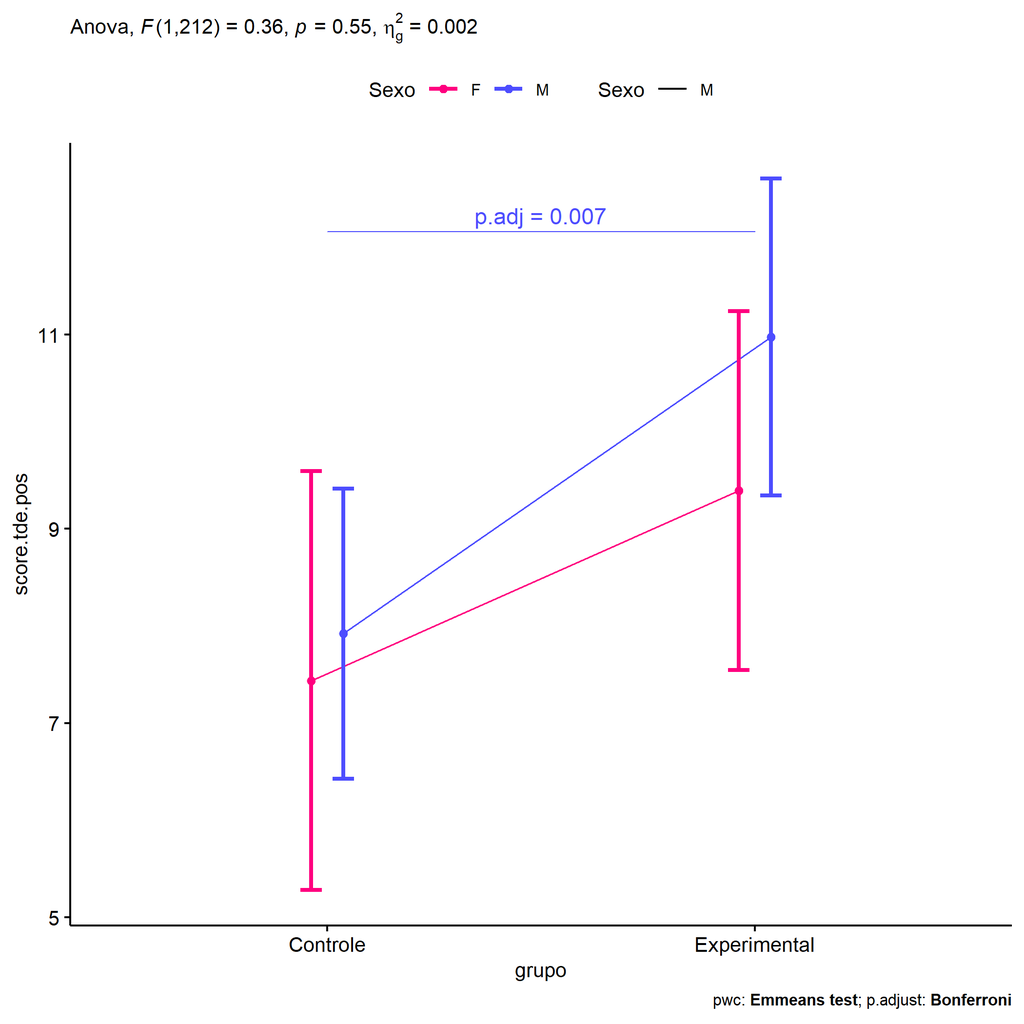

```r
if (!is.null(plots[["grupo"]]))
  plots[["grupo"]] + ggplot2::scale_color_manual(values = color[["Sexo"]])
```

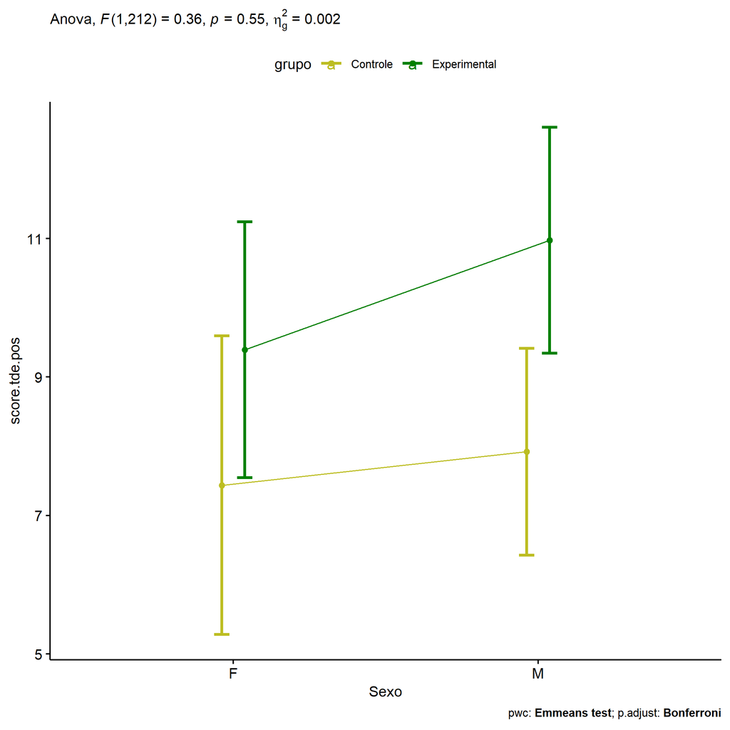

```r
if (!is.null(plots[["Sexo"]]))
  plots[["Sexo"]] + ggplot2::scale_color_manual(values = color[["grupo"]])
```

```r
plots <- twoWayAncovaBoxPlots(
  wdat, "score.tde.pos", c("grupo","Sexo"), aov, pwcs, covar = "score.tde.pre",
  theme = "classic", color = color[["grupo:Sexo"]],
  subtitle = which(aov$Effect == "grupo:Sexo"))
```

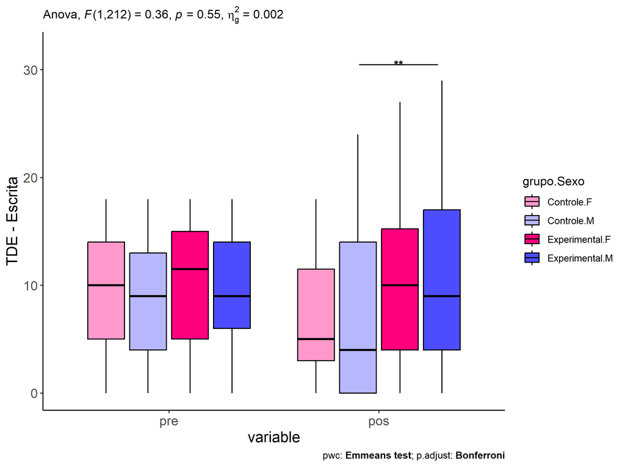

```r
plots[["grupo:Sexo"]] + ggplot2::ylab("TDE - Escrita") + ggplot2::scale_x_discrete(labels=c('pre', 'pos'))
```

```r
plots <- twoWayAncovaBoxPlots(
  wdat.long, "score.tde", c("grupo","Sexo"), aov, pwc.long, pre.post = "time",
  theme = "classic", color = color$prepost)
```

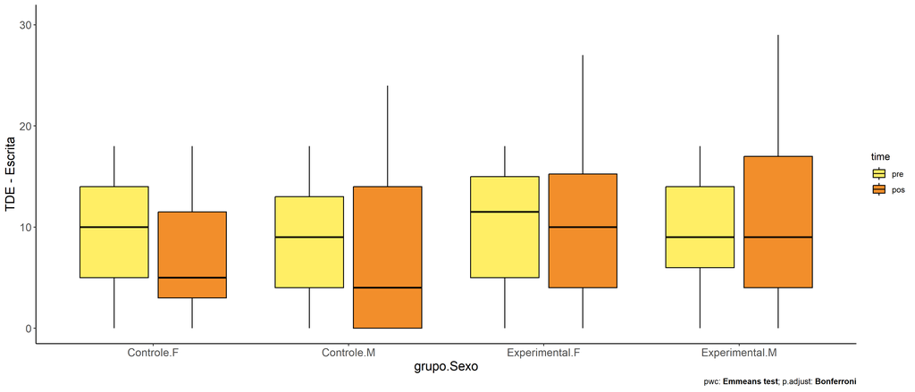

```r
plots[["grupo:Sexo"]] + ggplot2::ylab("TDE - Escrita")
```

### Checking linearity assumption

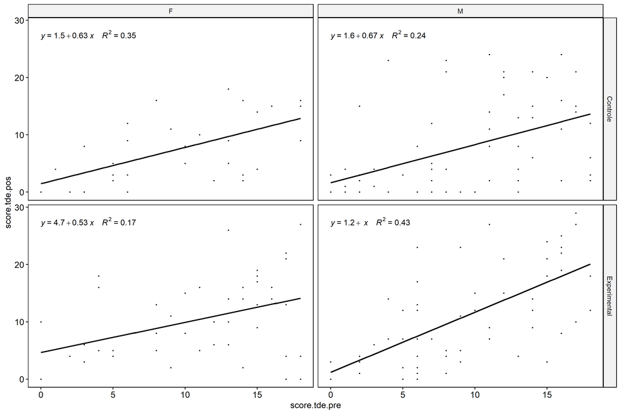

```r
ggscatter(wdat, x = "score.tde.pre", y = "score.tde.pos", size = 0.5,
          facet.by = c("grupo","Sexo"), add = "reg.line")+
  stat_regline_equation(
    aes(label =  paste(..eq.label.., ..rr.label.., sep = "~~~~"))
  )
```

### Checking normality and homogeneity

```r
res <- augment(lm(score.tde.pos ~ score.tde.pre + grupo*Sexo, data = wdat))
```

```r
shapiro_test(res$.resid)
```

```
## # A tibble: 1 × 3
##   variable   statistic p.value
##   <chr>          <dbl>   <dbl>
## 1 res$.resid     0.986  0.0370
```

```r
levene_test(res, .resid ~ grupo*Sexo)
```

```
## # A tibble: 1 × 4
##     df1   df2 statistic     p
##   <int> <int>     <dbl> <dbl>
## 1     3   213      1.54 0.204
```

# ANCOVA and Pairwise for two factors **grupo:Zona**

## Without remove non-normal data

```r
pdat = remove_group_data(dat[!is.na(dat[["grupo"]]) & !is.na(dat[["Zona"]]),], "score.tde.pos", c("grupo","Zona"))

pdat.long <- rbind(pdat[,c("id","grupo","Zona")], pdat[,c("id","grupo","Zona")])
pdat.long[["time"]] <- c(rep("pre", nrow(pdat)), rep("pos", nrow(pdat)))
pdat.long[["time"]] <- factor(pdat.long[["time"]], c("pre","pos"))
pdat.long[["score.tde"]] <- c(pdat[["score.tde.pre"]], pdat[["score.tde.pos"]])

aov = anova_test(pdat, score.tde.pos ~ score.tde.pre + grupo*Zona)
laov[["grupo:Zona"]] <- get_anova_table(aov)
```

```r
pwcs <- list()
pwcs[["Zona"]] <- emmeans_test(
  group_by(pdat, grupo), score.tde.pos ~ Zona,
  covariate = score.tde.pre, p.adjust.method = "bonferroni")
pwcs[["grupo"]] <- emmeans_test(
  group_by(pdat, Zona), score.tde.pos ~ grupo,
  covariate = score.tde.pre, p.adjust.method = "bonferroni")

pwc <- plyr::rbind.fill(pwcs[["grupo"]], pwcs[["Zona"]])
pwc <- pwc[,c("grupo","Zona", colnames(pwc)[!colnames(pwc) %in% c("grupo","Zona")])]
```

```r
pwc.long <- emmeans_test(dplyr::group_by_at(pdat.long, c("grupo","Zona")),
                         score.tde ~ time,
                         p.adjust.method = "bonferroni")
lpwc[["grupo:Zona"]] <- plyr::rbind.fill(pwc, pwc.long)
```

```r
ds <- get.descriptives(pdat, "score.tde.pos", c("grupo","Zona"), covar = "score.tde.pre")
ds <- merge(ds[ds$variable != "score.tde.pre",],
            ds[ds$variable == "score.tde.pre", !colnames(ds) %in% c("variable")],
            by = c("grupo","Zona"), all.x = T, suffixes = c("", ".score.tde.pre"))
ds <- merge(get_emmeans(pwcs[["grupo"]]), ds, by = c("grupo","Zona"), suffixes = c(".emms", ""))
ds <- ds[,c("grupo","Zona","n","mean.score.tde.pre","se.score.tde.pre","mean","se","emmean","se.emms")]

colnames(ds) <- c("grupo","Zona", "N", paste0(c("M","SE")," (pre)"),
                  paste0(c("M","SE"), " (unadj)"), paste0(c("M", "SE"), " (adj)"))

lemms[["grupo:Zona"]] <- ds
```

## Computing ANCOVA and PairWise After removing non-normal data (OK)

```r
wdat = pdat

res = residuals(lm(score.tde.pos ~ score.tde.pre + grupo*Zona, data = wdat))
non.normal = getNonNormal(res, wdat$id, plimit = 0.05)

wdat = wdat[!wdat$id %in% non.normal,]

wdat.long <- rbind(wdat[,c("id","grupo","Zona")], wdat[,c("id","grupo","Zona")])
wdat.long[["time"]] <- c(rep("pre", nrow(wdat)), rep("pos", nrow(wdat)))
wdat.long[["time"]] <- factor(wdat.long[["time"]], c("pre","pos"))
wdat.long[["score.tde"]] <- c(wdat[["score.tde.pre"]], wdat[["score.tde.pos"]])


ldat[["grupo:Zona"]] = wdat

(non.normal)
```

```
## [1] "P1971" "P809"  "P2004"
```

```r
aov = anova_test(wdat, score.tde.pos ~ score.tde.pre + grupo*Zona)
laov[["grupo:Zona"]] <- merge(get_anova_table(aov), laov[["grupo:Zona"]], by="Effect", suffixes = c("","'"))

(df = get_anova_table(aov))
```

```
## ANOVA Table (type II tests)
##
##          Effect DFn DFd      F        p p<.05   ges
## 1 score.tde.pre   1 164 61.162 6.06e-13     * 0.272
## 2         grupo   1 164  6.112 1.40e-02     * 0.036
## 3          Zona   1 164  2.461 1.19e-01       0.015
## 4    grupo:Zona   1 164  0.870 3.52e-01       0.005
```

| Effect | DFn | DFd | F | p | p<.05 | ges |
| --- | --- | --- | --- | --- | --- | --- |
| score.tde.pre | 1 | 164 | 61.162 | 0.000 | * | 0.272 |
| grupo | 1 | 164 | 6.112 | 0.014 | * | 0.036 |
| Zona | 1 | 164 | 2.461 | 0.119 |  | 0.015 |
| grupo:Zona | 1 | 164 | 0.870 | 0.352 |  | 0.005 |

```r
pwcs <- list()
pwcs[["Zona"]] <- emmeans_test(
  group_by(wdat, grupo), score.tde.pos ~ Zona,
  covariate = score.tde.pre, p.adjust.method = "bonferroni")
pwcs[["grupo"]] <- emmeans_test(
  group_by(wdat, Zona), score.tde.pos ~ grupo,
  covariate = score.tde.pre, p.adjust.method = "bonferroni")

pwc <- plyr::rbind.fill(pwcs[["grupo"]], pwcs[["Zona"]])
pwc <- pwc[,c("grupo","Zona", colnames(pwc)[!colnames(pwc) %in% c("grupo","Zona")])]
```

| grupo | Zona | term | .y. | group1 | group2 | df | statistic | p | p.adj | p.adj.signif |
| --- | --- | --- | --- | --- | --- | --- | --- | --- | --- | --- |
|  | Rural | score.tde.pre*grupo | score.tde.pos | Controle | Experimental | 164 | -2.616 | 0.010 | 0.010 | ** |
|  | Urbana | score.tde.pre*grupo | score.tde.pos | Controle | Experimental | 164 | -0.366 | 0.714 | 0.714 | ns |
| Controle |  | score.tde.pre*Zona | score.tde.pos | Rural | Urbana | 164 | 0.321 | 0.748 | 0.748 | ns |
| Experimental |  | score.tde.pre*Zona | score.tde.pos | Rural | Urbana | 164 | 1.796 | 0.074 | 0.074 | ns |

```r
pwc.long <- emmeans_test(dplyr::group_by_at(wdat.long, c("grupo","Zona")),
                         score.tde ~ time,
                         p.adjust.method = "bonferroni")
lpwc[["grupo:Zona"]] <- merge(plyr::rbind.fill(pwc, pwc.long), lpwc[["grupo:Zona"]], by=c("grupo","Zona","term",".y.","group1","group2"), suffixes = c("","'"))
```

| grupo | Zona | term | .y. | group1 | group2 | df | statistic | p | p.adj | p.adj.signif |
| --- | --- | --- | --- | --- | --- | --- | --- | --- | --- | --- |
| Controle | Rural | time | score.tde | pre | pos | 330 | 1.271 | 0.205 | 0.205 | ns |
| Controle | Urbana | time | score.tde | pre | pos | 330 | 0.885 | 0.377 | 0.377 | ns |
| Experimental | Rural | time | score.tde | pre | pos | 330 | -1.103 | 0.271 | 0.271 | ns |
| Experimental | Urbana | time | score.tde | pre | pos | 330 | 0.591 | 0.555 | 0.555 | ns |

```r
ds <- get.descriptives(wdat, "score.tde.pos", c("grupo","Zona"), covar = "score.tde.pre")
ds <- merge(ds[ds$variable != "score.tde.pre",],
            ds[ds$variable == "score.tde.pre", !colnames(ds) %in% c("variable")],
            by = c("grupo","Zona"), all.x = T, suffixes = c("", ".score.tde.pre"))
ds <- merge(get_emmeans(pwcs[["grupo"]]), ds, by = c("grupo","Zona"), suffixes = c(".emms", ""))
ds <- ds[,c("grupo","Zona","n","mean.score.tde.pre","se.score.tde.pre","mean","se","emmean","se.emms")]

colnames(ds) <- c("grupo","Zona", "N", paste0(c("M","SE")," (pre)"),
                  paste0(c("M","SE"), " (unadj)"), paste0(c("M", "SE"), " (adj)"))

lemms[["grupo:Zona"]] <- merge(ds, lemms[["grupo:Zona"]], by=c("grupo","Zona"), suffixes = c("","'"))
```

| grupo | Zona | N | M (pre) | SE (pre) | M (unadj) | SE (unadj) | M (adj) | SE (adj) |
| --- | --- | --- | --- | --- | --- | --- | --- | --- |
| Controle | Rural | 67 | 8.925 | 0.646 | 7.478 | 0.889 | 7.626 | 0.785 |
| Controle | Urbana | 16 | 9.062 | 1.529 | 7.000 | 1.981 | 7.052 | 1.606 |
| Experimental | Rural | 62 | 9.645 | 0.738 | 10.952 | 1.012 | 10.592 | 0.817 |
| Experimental | Urbana | 24 | 8.458 | 1.037 | 7.333 | 1.329 | 7.812 | 1.312 |

### Plots for ancova

```r
plots <- twoWayAncovaPlots(
  wdat, "score.tde.pos", c("grupo","Zona"), aov, pwcs, addParam = c("mean_se"),
  font.label.size=10, step.increase=0.05, p.label="p.adj",
  subtitle = which(aov$Effect == "grupo:Zona"))
```

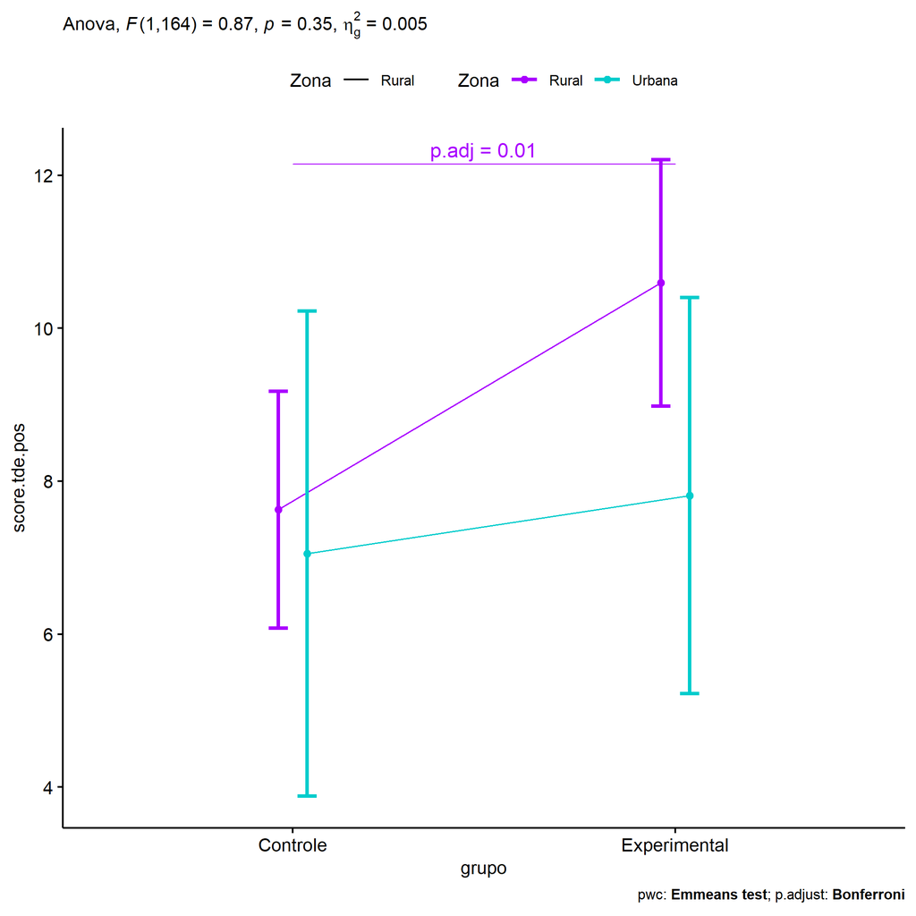

```r
if (!is.null(plots[["grupo"]]))
  plots[["grupo"]] + ggplot2::scale_color_manual(values = color[["Zona"]])
```

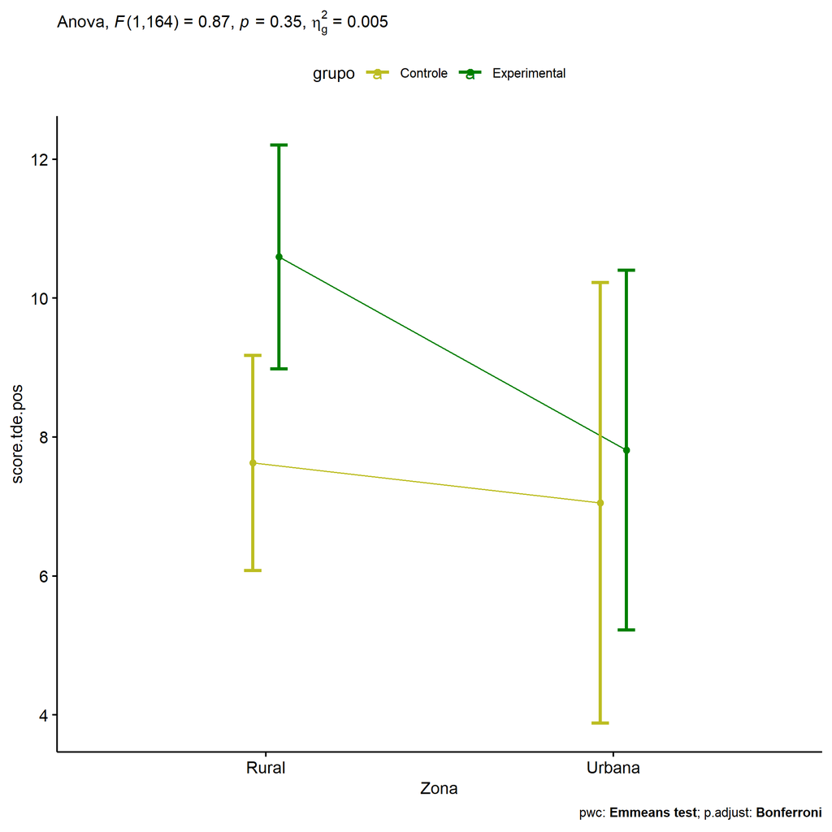

```r
if (!is.null(plots[["Zona"]]))
  plots[["Zona"]] + ggplot2::scale_color_manual(values = color[["grupo"]])
```

```r
plots <- twoWayAncovaBoxPlots(
  wdat, "score.tde.pos", c("grupo","Zona"), aov, pwcs, covar = "score.tde.pre",
  theme = "classic", color = color[["grupo:Zona"]],
  subtitle = which(aov$Effect == "grupo:Zona"))
```

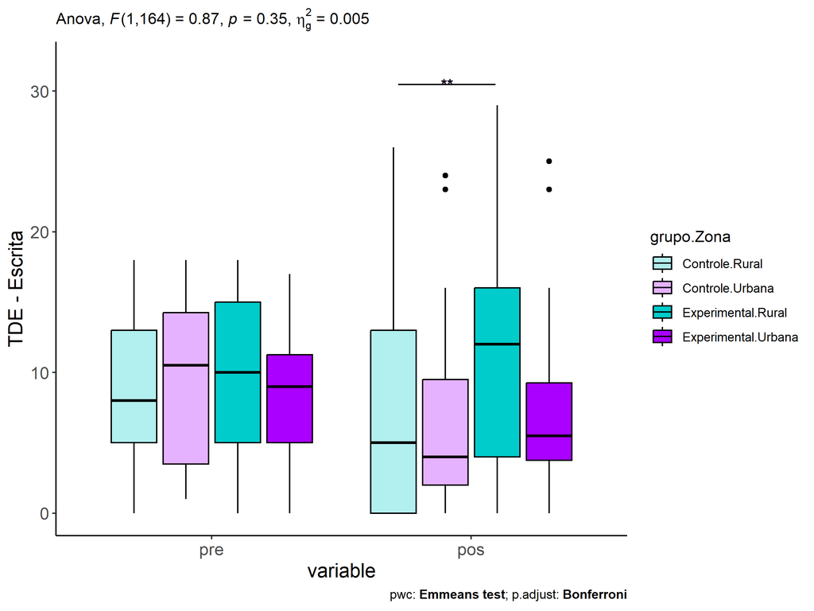

```r
plots[["grupo:Zona"]] + ggplot2::ylab("TDE - Escrita") + ggplot2::scale_x_discrete(labels=c('pre', 'pos'))
```

```r
plots <- twoWayAncovaBoxPlots(
  wdat.long, "score.tde", c("grupo","Zona"), aov, pwc.long, pre.post = "time",
  theme = "classic", color = color$prepost)
```

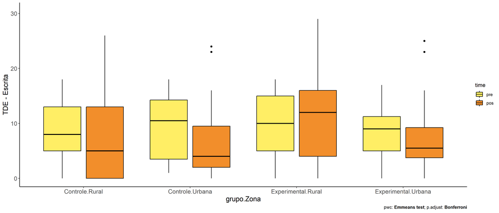

```r
plots[["grupo:Zona"]] + ggplot2::ylab("TDE - Escrita")
```

### Checking linearity assumption

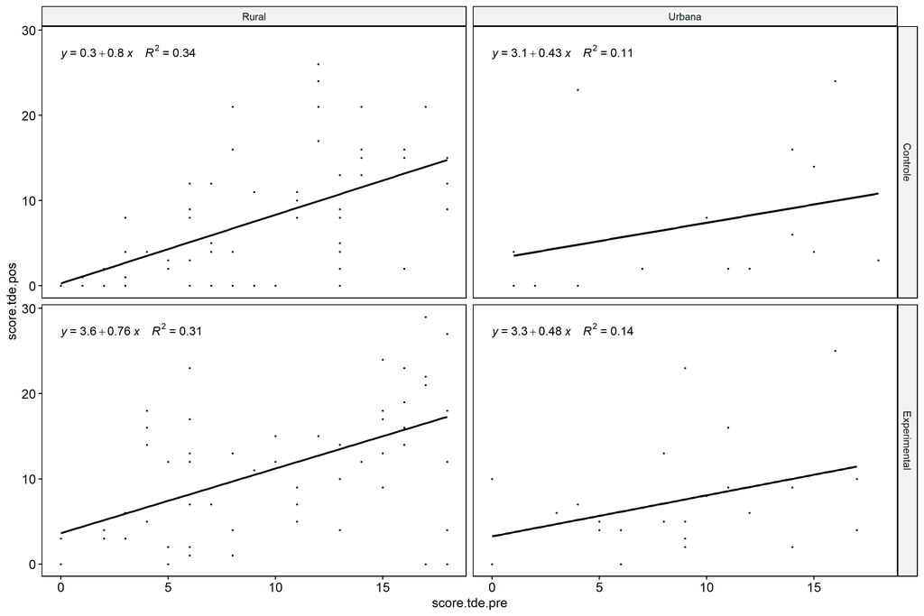

```r
ggscatter(wdat, x = "score.tde.pre", y = "score.tde.pos", size = 0.5,
          facet.by = c("grupo","Zona"), add = "reg.line")+
  stat_regline_equation(
    aes(label =  paste(..eq.label.., ..rr.label.., sep = "~~~~"))
  )
```

### Checking normality and homogeneity

```r
res <- augment(lm(score.tde.pos ~ score.tde.pre + grupo*Zona, data = wdat))
```

```r
shapiro_test(res$.resid)
```

```
## # A tibble: 1 × 3
##   variable   statistic p.value
##   <chr>          <dbl>   <dbl>
## 1 res$.resid     0.981  0.0195
```

```r
levene_test(res, .resid ~ grupo*Zona)
```

```
## # A tibble: 1 × 4
##     df1   df2 statistic     p
##   <int> <int>     <dbl> <dbl>
## 1     3   165     0.677 0.567
```

# ANCOVA and Pairwise for two factors **grupo:Cor.Raca**

## Without remove non-normal data

```r
pdat = remove_group_data(dat[!is.na(dat[["grupo"]]) & !is.na(dat[["Cor.Raca"]]),], "score.tde.pos", c("grupo","Cor.Raca"))

pdat.long <- rbind(pdat[,c("id","grupo","Cor.Raca")], pdat[,c("id","grupo","Cor.Raca")])
pdat.long[["time"]] <- c(rep("pre", nrow(pdat)), rep("pos", nrow(pdat)))
pdat.long[["time"]] <- factor(pdat.long[["time"]], c("pre","pos"))
pdat.long[["score.tde"]] <- c(pdat[["score.tde.pre"]], pdat[["score.tde.pos"]])

aov = anova_test(pdat, score.tde.pos ~ score.tde.pre + grupo*Cor.Raca)
laov[["grupo:Cor.Raca"]] <- get_anova_table(aov)
```

```r
pwcs <- list()
pwcs[["Cor.Raca"]] <- emmeans_test(
  group_by(pdat, grupo), score.tde.pos ~ Cor.Raca,
  covariate = score.tde.pre, p.adjust.method = "bonferroni")
pwcs[["grupo"]] <- emmeans_test(
  group_by(pdat, Cor.Raca), score.tde.pos ~ grupo,
  covariate = score.tde.pre, p.adjust.method = "bonferroni")

pwc <- plyr::rbind.fill(pwcs[["grupo"]], pwcs[["Cor.Raca"]])
pwc <- pwc[,c("grupo","Cor.Raca", colnames(pwc)[!colnames(pwc) %in% c("grupo","Cor.Raca")])]
```

```r
pwc.long <- emmeans_test(dplyr::group_by_at(pdat.long, c("grupo","Cor.Raca")),
                         score.tde ~ time,
                         p.adjust.method = "bonferroni")
lpwc[["grupo:Cor.Raca"]] <- plyr::rbind.fill(pwc, pwc.long)
```

```r
ds <- get.descriptives(pdat, "score.tde.pos", c("grupo","Cor.Raca"), covar = "score.tde.pre")
ds <- merge(ds[ds$variable != "score.tde.pre",],
            ds[ds$variable == "score.tde.pre", !colnames(ds) %in% c("variable")],
            by = c("grupo","Cor.Raca"), all.x = T, suffixes = c("", ".score.tde.pre"))
ds <- merge(get_emmeans(pwcs[["grupo"]]), ds, by = c("grupo","Cor.Raca"), suffixes = c(".emms", ""))
ds <- ds[,c("grupo","Cor.Raca","n","mean.score.tde.pre","se.score.tde.pre","mean","se","emmean","se.emms")]

colnames(ds) <- c("grupo","Cor.Raca", "N", paste0(c("M","SE")," (pre)"),
                  paste0(c("M","SE"), " (unadj)"), paste0(c("M", "SE"), " (adj)"))

lemms[["grupo:Cor.Raca"]] <- ds
```

## Computing ANCOVA and PairWise After removing non-normal data (OK)

```r
wdat = pdat

res = residuals(lm(score.tde.pos ~ score.tde.pre + grupo*Cor.Raca, data = wdat))
non.normal = getNonNormal(res, wdat$id, plimit = 0.05)

wdat = wdat[!wdat$id %in% non.normal,]

wdat.long <- rbind(wdat[,c("id","grupo","Cor.Raca")], wdat[,c("id","grupo","Cor.Raca")])
wdat.long[["time"]] <- c(rep("pre", nrow(wdat)), rep("pos", nrow(wdat)))
wdat.long[["time"]] <- factor(wdat.long[["time"]], c("pre","pos"))
wdat.long[["score.tde"]] <- c(wdat[["score.tde.pre"]], wdat[["score.tde.pos"]])


ldat[["grupo:Cor.Raca"]] = wdat

(non.normal)
```

```
## [1] "P3637"
```

```r
aov = anova_test(wdat, score.tde.pos ~ score.tde.pre + grupo*Cor.Raca)
laov[["grupo:Cor.Raca"]] <- merge(get_anova_table(aov), laov[["grupo:Cor.Raca"]], by="Effect", suffixes = c("","'"))

(df = get_anova_table(aov))
```

```
## ANOVA Table (type II tests)
##
##           Effect DFn DFd      F        p p<.05   ges
## 1  score.tde.pre   1 101 29.362 4.09e-07     * 0.225
## 2          grupo   1 101  4.921 2.90e-02     * 0.046
## 3       Cor.Raca   2 101  0.946 3.92e-01       0.018
## 4 grupo:Cor.Raca   1 101  2.921 9.10e-02       0.028
```

| Effect | DFn | DFd | F | p | p<.05 | ges |
| --- | --- | --- | --- | --- | --- | --- |
| score.tde.pre | 1 | 101 | 29.362 | 0.000 | * | 0.225 |
| grupo | 1 | 101 | 4.921 | 0.029 | * | 0.046 |
| Cor.Raca | 2 | 101 | 0.946 | 0.392 |  | 0.018 |
| grupo:Cor.Raca | 1 | 101 | 2.921 | 0.091 |  | 0.028 |

```r
pwcs <- list()
pwcs[["Cor.Raca"]] <- emmeans_test(
  group_by(wdat, grupo), score.tde.pos ~ Cor.Raca,
  covariate = score.tde.pre, p.adjust.method = "bonferroni")
pwcs[["grupo"]] <- emmeans_test(
  group_by(wdat, Cor.Raca), score.tde.pos ~ grupo,
  covariate = score.tde.pre, p.adjust.method = "bonferroni")

pwc <- plyr::rbind.fill(pwcs[["grupo"]], pwcs[["Cor.Raca"]])
pwc <- pwc[,c("grupo","Cor.Raca", colnames(pwc)[!colnames(pwc) %in% c("grupo","Cor.Raca")])]
```

| grupo | Cor.Raca | term | .y. | group1 | group2 | df | statistic | p | p.adj | p.adj.signif |
| --- | --- | --- | --- | --- | --- | --- | --- | --- | --- | --- |
|  | Branca | score.tde.pre*grupo | score.tde.pos | Controle | Experimental | 101 | -2.551 | 0.012 | 0.012 | * |
|  | Indígena | score.tde.pre*grupo | score.tde.pos | Controle | Experimental |  |  |  |  |  |
|  | Parda | score.tde.pre*grupo | score.tde.pos | Controle | Experimental | 101 | -1.153 | 0.252 | 0.252 | ns |
| Controle |  | score.tde.pre*Cor.Raca | score.tde.pos | Branca | Indígena |  |  |  |  |  |
| Controle |  | score.tde.pre*Cor.Raca | score.tde.pos | Branca | Parda | 101 | -1.377 | 0.172 | 0.172 | ns |
| Controle |  | score.tde.pre*Cor.Raca | score.tde.pos | Indígena | Parda |  |  |  |  |  |
| Experimental |  | score.tde.pre*Cor.Raca | score.tde.pos | Branca | Indígena | 101 | -0.866 | 0.388 | 1.000 | ns |
| Experimental |  | score.tde.pre*Cor.Raca | score.tde.pos | Branca | Parda | 101 | 1.008 | 0.316 | 0.947 | ns |
| Experimental |  | score.tde.pre*Cor.Raca | score.tde.pos | Indígena | Parda | 101 | 1.546 | 0.125 | 0.376 | ns |

```r
pwc.long <- emmeans_test(dplyr::group_by_at(wdat.long, c("grupo","Cor.Raca")),
                         score.tde ~ time,
                         p.adjust.method = "bonferroni")
lpwc[["grupo:Cor.Raca"]] <- merge(plyr::rbind.fill(pwc, pwc.long), lpwc[["grupo:Cor.Raca"]], by=c("grupo","Cor.Raca","term",".y.","group1","group2"), suffixes = c("","'"))
```

| grupo | Cor.Raca | term | .y. | group1 | group2 | df | statistic | p | p.adj | p.adj.signif |
| --- | --- | --- | --- | --- | --- | --- | --- | --- | --- | --- |
| Controle | Branca | time | score.tde | pre | pos | 204 | 1.458 | 0.146 | 0.146 | ns |
| Controle | Indígena | time | score.tde | pre | pos |  |  |  |  |  |
| Controle | Parda | time | score.tde | pre | pos | 204 | 0.419 | 0.676 | 0.676 | ns |
| Experimental | Branca | time | score.tde | pre | pos | 204 | -1.195 | 0.233 | 0.233 | ns |
| Experimental | Indígena | time | score.tde | pre | pos | 204 | -1.485 | 0.139 | 0.139 | ns |
| Experimental | Parda | time | score.tde | pre | pos | 204 | -0.604 | 0.547 | 0.547 | ns |

```r
ds <- get.descriptives(wdat, "score.tde.pos", c("grupo","Cor.Raca"), covar = "score.tde.pre")
ds <- merge(ds[ds$variable != "score.tde.pre",],
            ds[ds$variable == "score.tde.pre", !colnames(ds) %in% c("variable")],
            by = c("grupo","Cor.Raca"), all.x = T, suffixes = c("", ".score.tde.pre"))
ds <- merge(get_emmeans(pwcs[["grupo"]]), ds, by = c("grupo","Cor.Raca"), suffixes = c(".emms", ""))
ds <- ds[,c("grupo","Cor.Raca","n","mean.score.tde.pre","se.score.tde.pre","mean","se","emmean","se.emms")]

colnames(ds) <- c("grupo","Cor.Raca", "N", paste0(c("M","SE")," (pre)"),
                  paste0(c("M","SE"), " (unadj)"), paste0(c("M", "SE"), " (adj)"))

lemms[["grupo:Cor.Raca"]] <- merge(ds, lemms[["grupo:Cor.Raca"]], by=c("grupo","Cor.Raca"), suffixes = c("","'"))
```

| grupo | Cor.Raca | N | M (pre) | SE (pre) | M (unadj) | SE (unadj) | M (adj) | SE (adj) |
| --- | --- | --- | --- | --- | --- | --- | --- | --- |
| Controle | Branca | 8 | 9.875 | 1.630 | 4.750 | 2.024 | 3.930 | 2.550 |
| Controle | Parda | 39 | 8.026 | 0.936 | 7.359 | 1.206 | 7.791 | 1.156 |
| Experimental | Branca | 17 | 9.471 | 1.539 | 12.353 | 2.526 | 11.806 | 1.749 |
| Experimental | Indígena | 5 | 7.800 | 1.800 | 14.400 | 3.709 | 14.985 | 3.222 |
| Experimental | Parda | 38 | 8.816 | 0.910 | 9.789 | 1.297 | 9.686 | 1.168 |